# Tugas: Evaluasi Model (due date: 13 Juni 2023)

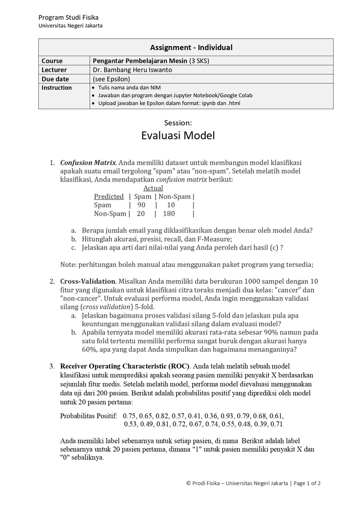

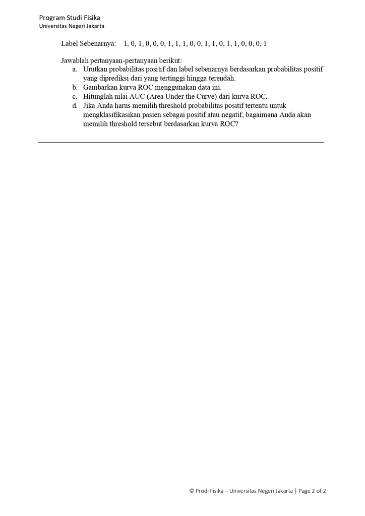

- Nama : Muhammad Rizky Anugrah
- NIM : 1306620089
- Kelas : Fisika - B
- Angkatan : 2020
- Dosen Pengampu : Dr.rer.nat. Bambang Heru Iswanto

## IMPORT

```python
import numpy as np
import pandas as pd
import matplotlib.pyplot as plt
import warnings
warnings.filterwarnings('ignore')
import seaborn as sns
from sklearn.metrics import roc_auc_score, roc_curve, auc
```

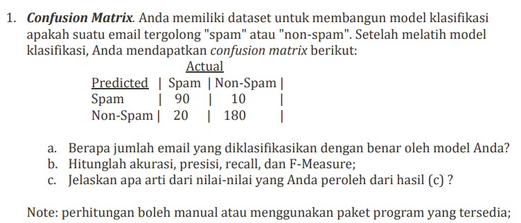

```python
TP = 90
FP = 10
FN = 20
TN = 180
cm = np.array([[TP,FP],[FN,TN]])
```

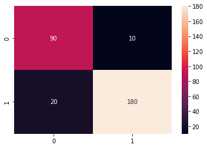

```python
sns.heatmap(cm,annot=True,fmt="d")
```

## 1.a

```python
TP + TN
```

```
270
```

Jumlah email yang diklasifikasikan dengan benar oleh model yaitu True Positive + True Negative = 270

## 1. b

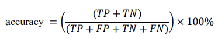

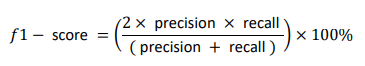

```python
accuracy = ( TP + TN ) / ( TP + FP + TN + FN )
precision = TP / ( TP + FP )
recall = TP / ( TP + FN )
FMeasure_F1Score = ( 2 * precision * recall) / ( precision + recall )
```

```python
print(f'Accuracy = {accuracy * 100:.2f}%')
print(f'Precision = {precision * 100:.2f}%')
print(f'Recall = {recall * 100:.2f}%')
print(f'F-Measure = {FMeasure_F1Score * 100:.2f}%')
```

```
Accuracy = 90.00%
Precision = 90.00%
Recall = 81.82%
F-Measure = 85.71%
```

## 1.c

1. Accuracy: 90.00%
- Accuracy (akurasi) mengukur sejauh mana model klasifikasi berhasil mengklasifikasikan dengan benar seluruh sampel data. Dalam konteks ini, accuracy sebesar 90.00% berarti model secara benar mengklasifikasikan 90.00% dari semua sampel data dengan benar.
1. Precision: 90.00%
- Precision (presisi) mengukur sejauh mana prediksi positif yang dibuat oleh model klasifikasi adalah benar. Dalam konteks ini, precision sebesar 90.00% berarti 90.00% dari prediksi positif yang dilakukan oleh model adalah benar.
1. Recall: 81.82%
- Recall (recall atau true positive rate) mengukur sejauh mana model klasifikasi berhasil mendeteksi dan mengklasifikasikan dengan benar semua sampel data yang sebenarnya positif. Dalam konteks ini, recall sebesar 81.82% berarti model berhasil mendeteksi dan mengklasifikasikan dengan benar 81.82% dari semua sampel data yang sebenarnya positif.
1. F-Measure: 85.71%
- F-Measure (F-Score atau F1-Score) adalah ukuran gabungan yang menggabungkan precision dan recall menjadi satu nilai tunggal yang mewakili kinerja keseluruhan model klasifikasi. F-Measure menggunakan rata-rata harmonik antara precision dan recall, memberikan perhatian yang seimbang pada keduanya. Dalam konteks ini, F-Measure sebesar 85.71% menunjukkan tingkat keseimbangan yang baik antara precision dan recall dalam model klasifikasi tersebut.

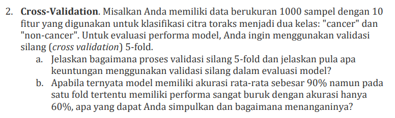

## 2.a

a. Proses validasi silang 5-fold melibatkan pembagian data menjadi 5 subset yang sama ukurannya (k-fold), di mana 4 subset digunakan sebagai data pelatihan (training set) dan subset yang tersisa digunakan sebagai data validasi (validation set). Selanjutnya, model dilatih dan dievaluasi sebanyak 5 kali, di mana setiap kali fold yang berbeda digunakan sebagai data validasi, sementara sisa fold digunakan sebagai data pelatihan. Hasil evaluasi, seperti akurasi atau metrik lainnya, dihitung dan dicatat untuk setiap iterasi. Akhirnya, hasil evaluasi dari 5 iterasi digunakan untuk menghitung rata-rata dan variasi kinerja model.

Keuntungan menggunakan validasi silang dalam evaluasi model adalah sebagai berikut:

- Mencegah overfitting: Dengan menggunakan validasi silang, model dievaluasi pada subset data yang berbeda secara bergantian. Ini membantu menghindari kecenderungan model untuk "menghafal" atau overfitting pada satu set data tertentu.
- Memanfaatkan data secara maksimal: Dalam validasi silang 5-fold, model dilatih dan dievaluasi pada semua sampel data. Dengan demikian, kita dapat memanfaatkan data secara maksimal dalam proses evaluasi model.
- Menyediakan estimasi yang lebih andal: Dengan menggabungkan hasil evaluasi dari beberapa iterasi, seperti menghitung rata-rata atau variasi kinerja model, kita mendapatkan estimasi yang lebih andal tentang kinerja model secara umum.

## 2.b

b. Jika model memiliki akurasi rata-rata sebesar 90% namun pada satu fold tertentu memiliki performa yang sangat buruk dengan akurasi hanya 60%, hal itu dapat menunjukkan adanya variabilitas dalam kinerja model tergantung pada subset data yang digunakan. Beberapa kemungkinan penyebab antara lain:

- Fold tersebut mewakili kasus yang lebih sulit atau memiliki karakteristik yang berbeda dari fold lainnya.
- Data pada fold tersebut tidak representatif secara acak, sehingga hasilnya tidak mewakili kinerja model secara keseluruhan.

Untuk menangani situasi ini, langkah-langkah berikut dapat diambil:

- Periksa apakah ada kesalahan atau masalah dalam preprocessing data atau pembagian fold yang menyebabkan hasil yang tidak wajar pada fold tersebut.
- Cek kembali apakah metode evaluasi atau metrik yang digunakan sesuai dengan karakteristik data dan tujuan evaluasi.
- Lakukan analisis lebih lanjut terhadap subset data yang buruk performanya untuk mencari penyebabnya, seperti ketidakseimbangan kelas, data yang berkualitas buruk, atau karakteristik unik dari subset tersebut.
- Jika memungkinkan, pertimbangkan untuk menggunakan teknik seperti stratifikasi atau oversampling/undersampling untuk mengatasi ketidakseimbangan kelas.
- Selain itu, bisa juga mencoba variasi model atau metode lain yang lebih robust terhadap karakteristik data tertentu.

Penting untuk diingat bahwa evaluasi model hanya berdasarkan satu fold tidak cukup untuk mengambil kesimpulan keseluruhan tentang kinerja model. Dalam kasus seperti itu, perlu dilakukan analisis lebih lanjut dan penilaian menggunakan hasil evaluasi dari semua fold.

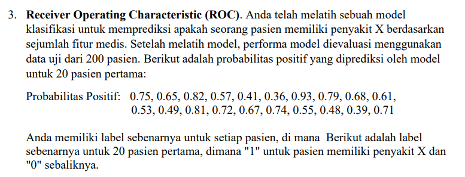

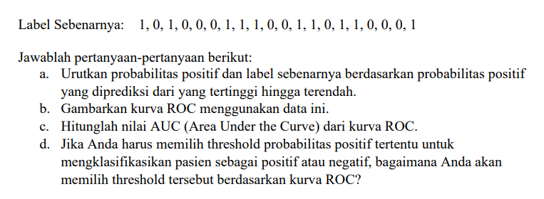

```python
probabilitas_positif = [0.75, 0.65, 0.82, 0.57, 0.41, 0.36, 0.93, 0.79, 0.68, 0.61,
            0.53, 0.49, 0.81, 0.72, 0.67, 0.74, 0.55, 0.48, 0.39, 0.71]

label_sebenarnya = [1, 0, 1, 0, 0, 0, 1, 1, 1, 0, 0, 1, 1, 0, 1, 1, 0, 0, 0, 1]

dataset = pd.DataFrame({'probabilitas' : probabilitas_positif,
                      'label' : label_sebenarnya})
```

```python
dataset
```

|  | probabilitas | label |
| --- | --- | --- |
| 0 | 0.75 | 1 |
| 1 | 0.65 | 0 |
| 2 | 0.82 | 1 |
| 3 | 0.57 | 0 |
| 4 | 0.41 | 0 |
| 5 | 0.36 | 0 |
| 6 | 0.93 | 1 |
| 7 | 0.79 | 1 |
| 8 | 0.68 | 1 |
| 9 | 0.61 | 0 |
| 10 | 0.53 | 0 |
| 11 | 0.49 | 1 |
| 12 | 0.81 | 1 |
| 13 | 0.72 | 0 |
| 14 | 0.67 | 1 |
| 15 | 0.74 | 1 |
| 16 | 0.55 | 0 |
| 17 | 0.48 | 0 |
| 18 | 0.39 | 0 |
| 19 | 0.71 | 1 |

## 3.a

```python
dataset_sorted = dataset.sort_values(by='probabilitas', ascending=False)
print(dataset_sorted)
```

```
    probabilitas  label
6           0.93      1
2           0.82      1
12          0.81      1
7           0.79      1
0           0.75      1
15          0.74      1
13          0.72      0
19          0.71      1
8           0.68      1
14          0.67      1
1           0.65      0
9           0.61      0
3           0.57      0
16          0.55      0
10          0.53      0
11          0.49      1
17          0.48      0
4           0.41      0
18          0.39      0
5           0.36      0
```

## 3.b

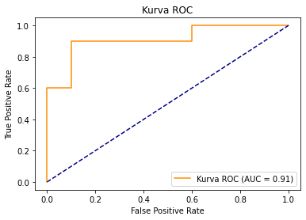

```python
# Menghitung nilai true positive rate (TPR) dan false positive rate (FPR)
fpr, tpr, thresholds = roc_curve(dataset_sorted['label'], dataset_sorted['probabilitas'])

# Menghitung nilai AUC (Area Under the Curve)
auc_score = auc(fpr, tpr)

# Membuat plot kurva ROC
plt.figure()
plt.plot(fpr, tpr, color='darkorange', label='Kurva ROC (AUC = %0.2f)' % auc_score)
plt.plot([0, 1], [0, 1], color='navy', linestyle='--')
plt.xlabel('False Positive Rate')
plt.ylabel('True Positive Rate')
plt.title('Kurva ROC')
plt.legend(loc="lower right")
plt.show()
```

## 3.c

```python
print("Nilai AUC: %.2f" % auc_score)
```

```
Nilai AUC: 0.91
```

## 3.d

```python
# Memilih threshold berdasarkan TPR dan FPR tertentu
desired_fpr = 0.2  # Misalnya, ingin FPR sebesar 0.2
idx = np.argmax(fpr >= desired_fpr)  # Menemukan indeks di mana FPR memenuhi kriteria
desired_threshold = thresholds[idx]  # Mengambil threshold yang sesuai dengan indeks
print("Threshold yang sesuai dengan FPR %.2f: %.2f" % (desired_fpr, desired_threshold))
```

```
Threshold yang sesuai dengan FPR 0.20: 0.53
```